# Chapter 3. Higher-Order Differential Equations

## Contents

- Theory of Linear Equations
- Reduction of Order
- Homogeneous Linear Equations with Constant Coefficients
- Undetermined Coefficients
- Variation of Parameters
- Cauchy-Euler Equations
- Nonlinear Equations
- Linear Models: IVPs
- Linear Models: BVPs
- Green's Functions
- Nonlinear Models
- Solving Systems of Linear Equations

## 3.1 Theory of Linear Equations

- In an **initial-value problem (IVP)**, we seek a solution $y(x)$ of a $n$-th order linear DE so that $y(x)$ satisfies **initial conditions** at $x_0$
  - $n$-th order linear DE: $\;a_n(x) \neq 0$

    $\displaystyle a_n(x) \frac{d^ny}{dx^n} +a_{n-1}(x) \frac{d^{n-1}y}{dx^{n-1}} +\cdots + a_1(x) \frac{dy}{dx} +a_0(x) y= g(x)\;$ or $\underbrace{L(y)}_{\mathrm{Linear\;Operator}}=g(x)$
  - Initial conditions

    $y(x_o) = y_o, \; y'(x_0) = y_1, \cdots, y^{(n-1)}(x_0) = y_{n-1}$
- **Boundary-value problem (BVP)** consists of solving a linear DE of order 2 or greater, in which the dependent variable $y$ or its derivatives are specified at *diffenrent points*. For example,
  - $\displaystyle a_2(x) \frac{d^2y}{dx^2} +a_1(x) \frac{dy}{dx} +a_0(x)y=g(x)$
  - Boundary conditions

    $y(x_0)=y_0, \;y(x_1)=y_1$
- The sum, or **superposition**, of two or more solutions of a homogeneous linear DE is also a solution
- Any set of $n$ linearly *independent* solutions $y_1, y_2, \cdots, y_n$ of the $n$-th order homogeneous linear DE on interval $I$ is **a fundamental set of solutions**
  - If two functions are linearly dependent, then one is a constant multiple of the other (otherwise, they are linearly independent)
  - If $\{y_1, y_2, \cdots, y_n\}$ are a set of linearly independent functions, the **Wronskian** function is not singular:

  > $W(y_1, y_2, \cdots, y_n)= \begin{vmatrix} y_1 & y_2 & \cdots & y_n \\ y_1' & y_2' & \cdots & y_n'\\ \vdots & \vdots & \cdots & \vdots\\ y_1^{(n-1)} & y_2^{(n-1)} & \cdots & y_n^{(n-1)} \end{vmatrix} \neq 0$
- General solution of $n$-th order homogeneous linear DE is

  $y(x)=c_1 y_1(x) +c_2 y_2(x) + \cdots + c_n y_n(x)$

  where $y_1, y_2, \cdots, y_n$ is a fundamental set of solutions and $c_i, \;i=1,2,\cdots,n$ are arbitrary constants
- General solution of $n$-th order nonhomogeneous linear DE is

  $y(x)=c_1 y_1(x) +c_2 y_2(x) + \cdots + c_n y_n(x) +y_p(x)$

  where $y_1, y_2, \cdots, y_n$ is a fundamental set of solutions, $y_p$ is a particular solution, and $c_i, \;i=1,2,\cdots,n$ are arbitrary constants

### Exercises 3.1

- 7, 8
- 15, 17
- 23, 25
- 31, 33

## 3.2 Reduction of Order

- **Reduction of order** can be used to reduce a linear second-order DE with known solution $y_1$ into a linear first-order DE, which can be solved for a second solution $y_2$
- Applying reduction of order $y_2 = u(x) y_1$ to the standard form of a second-order linear homogeneous DE

  $y''+P(x)y' +Q(x)y=0$

  gives

> $\displaystyle \begin{align*} y_1 u'' & +\left(2y_1' +P(x)y_1\right) u' = 0\\ &\;\big\Downarrow \;\times\; y_1, \; u'=w\\ (y_1^2 w)' &= -(y_1^2 w) P(x) \\ &\;\big\Downarrow \\ y_2(x) &= y_1(x) \int \frac{\exp\left( -\int P(x) \,dx \right)}{y_1^2(x)} \,dx \end{align*} $

### Exercises 3.2

- 1, 3, 5, 21

## 3.3 Homogeneous Linear Equations with Constant Coefficient

The general solution of $ay''+by'+cy=0$ is found by substituting $y=e^{px}$ and solving the resulting **characteristic equation** $ap^2+bp+c=0$ for roots $p_1$ and $p_2$

- **Case I**

  $p_1$ and $p_2$ are real and distinct

  $y = c_1 e^{p_1x} +c_2e^{p_2x}$
- **Case II**

  $p_1$ and $p_2$ are real and equal

  $y=c_1 e^{p_1x} +c_2 x e^{p_1x}$
- **Case III**

  $p_1$ and $p_2$ are complex conjugate: $p_1, p_2 = \alpha \pm i\beta$

  $y=e^{\alpha x} \left(c_1 \cos\beta x +c_2 \sin\beta x \right)$

**Example:** Solve $y'' +\omega^2y=0$ and $y'' -\omega^2y=0$

**Example:** Solve $3y'''+5y''+10y'-4y=0$

```python
from sympy.solvers import solve
from sympy import Symbol

x = Symbol('x')
solve(3*x**3 +5*x**2 +10*x -4, x)
```

```
[1/3, -1 - sqrt(3)*I, -1 + sqrt(3)*I]
```

### Exercises 3.3

- 1, 3, 5
- 15, 17, 19
- 29, 37

## 3.4 Undetermined Coefficients

**Method of undetermined coefficients** can be used to obtain a particular solution $y_p$

- The underlying idea is a conjecture about the form of $y_p$ based on the kinds of functions making up the input function $g(x)$
- Limited to nonhomogeneous linear DEs where
  - Coefficients $a_i, i=1,\cdots,n$ are constants
  - $g(x)$ is a constant, a polynominal function, $e^{\alpha x}$, $\sin\beta x$ or $\cos\beta x$, or finite sums and products of these functions
  - There are models of $y_p$ for various functions

[figure not shown]

- Finally, the general solution is obtained from the superposition of $y_h$ and $y_p$

**Example:** Solve $y'' +4y = x\cos x$

**Example:** Solve $y'' -6y' +9y = 6x^2 +2 -12e^{3x}$

- If $g(x)$ consists of a sum of, say, $m$ terms of the kind listed in the table, then the assumption for a particular solution $y_p$ consists of the sum of the trial forms
- If $y_p$ contains terms that duplicate terms in $y_h$, then that $y_p$ must be multiplied by $x^n$, where $n$ is the smallest positive integer that eliminate that duplication

**Example:** Solve $y^{(4)}+y'''= 1 -x^2e^{-x}$

### Exercises 3.4

- 19, 20, 21
- 27, 29, 33, 42

## 3.5 Variation of Parameters

The **method of variation of parameters** can be used with linear higher-order DEs.

- This method *always* yields a $y_p$ provided the homogeneous equation can be solved
- This method is not limited to the types of input functions constraining the method of undetermined coefficients

To adapt the method of variation of parameters to a linear second-order DE

> $a_1(x)y'' +a_1(x)y' +a_0(x)y = g(x)$,

we put the above equation in the standard form

> $y'' +P(x)y' +Q(x)y = f(x)$.

To solve,

- Find the homogeneous solutions $y_1, y_2$
- Seek a particular solution of the form $\;y_p = u_1(x) y_1 +u_2(x) y_2$

> $ \begin{align*} y_p''+P(x)y_p' +Q(x)y_p &= f(x)\\ &\Downarrow y_p = c_1 y_1 +c_2 y_2 \\ \frac{d}{dx}[y_1 u_1' +y_2 u_2'] +P(x) [y_1 u_1' +y_2 u_2'] +y_1' u_1' +y_2' u_2'&= f(x) \\ &\Downarrow y_1 u_1' +y_2 u_2' =0 \;(\mathrm{Assumption})\\ y_1' u_1' +y_2' u_2'&= f(x) \\ &\Downarrow \\ \begin{bmatrix} y_1 & y_2\\ y_1' & y_2' \end{bmatrix} \begin{bmatrix} u_1' \\ u_2' \end{bmatrix} &= \begin{bmatrix} 0 \\ f(x) \end{bmatrix} \\ &\Downarrow \\ u_1 = \displaystyle\int \frac{W_1}{W\;} \,dx =-\int \frac{y_2}{W}f(x)\,dx, \; &u_2 = \displaystyle\int \frac{W_2}{W\;} \,dx =\int \frac{y_1}{W}f(x)\,dx\\ \mathrm{where} \;\; W = \begin{bmatrix} y_1 & y_2\\ y_1' & y_2' \end{bmatrix}, \; W_1 =& \begin{bmatrix} 0 & y_2\\ f(x) & y_2' \end{bmatrix}, \; W_2 = \begin{bmatrix} y_1 & 0\\ y_1' & f(x) \end{bmatrix} \end{align*} $

**Example:** Solve $y'' -y = \frac{1}{x}$

The method can be generalized to the standard form of $n$-th order linear DE. A particular solution is

> $y_p = u_1(x) y_1 +u_2(x) y_2 +\cdots +u_n(x) y_n$

where

> $u_k = \displaystyle\int \frac{W_k}{W\;}\, dx, \;k=1, 2, \cdots, n$

### Exercises 3.5

- 1, 3, 5
- 19, 21, 23, 25
- 28, 30

## 3.6 Cauchy-Euler Equation

The **Cauchy-Euler equation** is a linear DE of the form

> $\displaystyle a_n x^n \frac{d^n y}{dx^n} +a_{n-1} x^{n-1} \frac{d^{n-1} y}{dx^{n-1}} +\cdots +a_1 x \frac{dy}{dx} +a_0 y = g(x)$

where $a_n, a_{n-1}, \cdots, a_0$ are constants and the exponent of the coefficient matches the order of differentiation.

$y =x^p$ is a solution of second-order DE whenever $p$ is a solution of the **auxiliary equation**

> $ap^2 +(b-a)p +c =0$
- **Case I:** Distinct Real Roots, $p_1, p_2$

  $y = c_1 x^{p_1} +c_2 x^{p_2}$
- **Case II:** Repeated Real Roots, $p_1=p_2$

  $y = c_1 x^{p_1} +c_2 x^{p_1} \ln x$
- **Case III:** Complex Conjugate Roots, $p_1, p_2 = \alpha +i\beta$

  $y =x^{\alpha}\left[c_1\cos(\beta\ln x) +c_2\sin(\beta\ln x) \right]$

**Example:** Solve $x^2y'' -3xy' +3y = 2x^4 e^x$

### Exercises 3.6

- 1, 3 ,5
- 19, 23
- 39, 43, 49

## 3.7 Nonlinear Equations

- Nonlinear equations do not possess superposability

  **Example:** Verify that $y_1$ and $y_2$ are solutions of the given DE but that $c_1 y_1 +c_2 y_2$ is, in general, not a solution

  > $\left(y''\right)^2 = y^2;$ $y_1=e^x$, $y_2=\cos x$
- The major difference between linear and nonlinear DEs of order two or higher lies in the realm of solvability. Nonlinear higher-order DEs virtually defy solution. This means that there are no analytical methods whereby either an explicit or implicit solution can be found
- There are still things that can be done; we can always analyze a nonlinear DE qualitatively and numerically
- Nonlinear second-order DEs $F(x, y', y'')=0$ and $F(y, y', y'')=0\,$ can be reduced to a first-order equation by means of the substitution $u=y'$ and can sometimes be solved using first-order methods

  **Exampe:** Solve $y''=2x(y')^2$ and $yy''=(y')^2$
- In some instances, a solution of a nonlinear IVP can be approximated by a Taylor series centered at $x_0$

  **Example:** Solve $y''=x +y -y^2$, $y(0)=-1$, $y'(0)=1$ by using

  $\displaystyle y(x) = y(0) +\frac{y'(0)}{1!}x +\frac{y''(0)}{2!}x^2 +\frac{y'''(0)}{3!} x^3 + \cdots$
- In order to analyze an $n$-th order IVP numerically, we express the $n$-th order ODE as a system of $n$ first-order equations. For example

  $ \begin{align*} \frac{d^2y}{dx^2} = f(x,y,y')&, \;\;y(x_0)=y_0, \;y'(x_0) = y_1\\ &\Downarrow y''=u'\\ \mathrm{Solve:} &\; \begin{cases} y' = u \\ u' = f(x,y,u) \end{cases}\\ \mathrm{Subject \;to:} & \;y(x_0)=y_0, \;u(x_0)=y_1 \end{align*} $

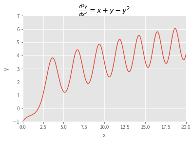

```python
%matplotlib inline
from scipy.integrate import solve_ivp
import numpy as np
import matplotlib.pyplot as plt
plt.style.use('ggplot')

def myODE(t, y):
    return [y[1], t +y[0] -y[0]*y[0]]

sol = solve_ivp(myODE, [0, 20], [-1, 1], t_eval = np.linspace(0, 20, 200))

plt.figure(figsize=(6, 4))
plt.plot(sol.t, sol.y[0])
plt.axis((0, 20, -1, 7))
plt.xlabel('x')
plt.ylabel('y')
plt.title(r'$\frac{d^2y}{dx^2}=x +y -y^2$')
plt.show()
```

### Exercises 3.7

- 3, 7, 13, 15

## 3.8 Linear Models: Initial-Value Problems

Several dynamical systems are modeled with linear second-order DEs with constant coefficients and initial conditions at $t_0$

- Spring/Mass Systems
  - Free Undamped Motion
  - Free Damped Motion
  - Diriven Motion

[figure not shown]

> $\displaystyle m\frac{d^2x}{dt^2} = -kx -\beta\frac{dx}{dt} +f(t)$,

> $x(0)=x_0$, $\dot{x}(0)=x_1$

### Exercises 3.8

- 43, 44, 45

## 3.9 Linear Models: Boundary-Value Problems

**Example: Temperature in a Ring**

The temperature $u(r)$ in circular ring is determined from the boundary-value problem

[figure not shown]

$r\displaystyle\frac{d^2 u}{dr^2} +\frac{du}{dr}=0$, $u(a)=u_0$, $u(b)=u_1$

## 3.10 Green's Functions

- **Initial-value problem**

  $ \begin{align*} y'' +P(x)y' +Q(x)y &= f(x), \;y(x_0)=y_0,\; y'(x_0)=y_1\\ &\Downarrow \\ y_h'' +P(x)y_h' +Q(x)y_h &= 0, \;\;\;\;\;y_h(x_0)=y_0,\; y_h'(x_0)=y_1 \\ &\;+ \\ y_p'' +P(x)y_p' +Q(x)y_p &= f(x), \;y_p(x_0)=0,\;\; y_p'(x_0)=0 \\ &\Downarrow \\ y_h(x) &= c_1 y_1(x) +c_2 y_2(x) \\ &\;+ \\ y_p(x) &= u_1(x) y_1(x) +u_2(x) y_2(x) \\ &= y_1(x)\int_{x_0}^x \frac{-y_2(t)f(t)}{W(t)}\,dt +y_2(x)\int_{x_0}^x \frac{y_1(t)f(t)}{W(t)}\,dt \\ &=\int_{x_0}^x \frac{y_1(t)y_2(x) -y_1(x)y_2(t)}{W(t)}f(t)\,dt \\ &=\int_{x_0}^x \underbrace{G(x,t)}_{\text{Green's function}} f(t) \,dt \end{align*} $
- **Boundary-value problem**

  $\displaystyle \begin{align*} y'' +P(x)y' +Q(x)y &= f(x)\\ A_1 y(a) +B_1 y'(a) &= 0\\ A_2 y(b) +B_2 y'(b) &= 0\\ &\Downarrow \\ y_h'' +P(x)y_h' +Q(x)y_h &= 0 \\ A_1 y_h(a) +B_1 y_h'(a) &= 0\\ A_2 y_h(b) +B_2 y_h'(b) &= 0\\ &\;+ \\ y_p'' +P(x)y_p' +Q(x)y_p &= f(x) \\ A_1 y_p(a) +B_1 y_p'(a) &= 0\\ A_2 y_p(b) +B_2 y_p'(b) &= 0\\ &\Downarrow \\ y_h(x) &= 0 \\ &\;+ \\ y_p(x) &= u_1(x) y_1(x) +u_2(x) y_2(x) \\ &\text{ }\\ &\Bigg\Downarrow\;\begin{matrix} u_2(a)=0,& A_1 y_1(a)+B_1 y_1'(a)=0\\ u_1(b)=0,& A_2 y_2(b)+B_2 y_2'(b)=0 \end{matrix} \\ &\text{ } \\ &= y_1(x)\int_{b}^x \frac{-y_2(t)f(t)}{W(t)}\,dt +y_2(x)\int_{a}^x \frac{y_1(t)f(t)}{W(t)}\,dt \\ &= \int_{a}^x \frac{y_2(x) y_1(t)}{W(t)}f(t)\,dt +\int_{x}^b \frac{y_1(x) y_2(t)}{W(t)}f(t)\,dt \\ &= \int_a^b G(x,t) f(t) \,dt \\ &\text{where }G(x,t)=\left\{\begin{matrix}\frac{y_1(t) y_2(x)}{W(t)}, & a \leq t \leq x \\ \frac{y_1(x) y_2(t)}{W(t)}, & x \leq t \leq b \end{matrix}\right. \end{align*} $

> **Example:** Solve $x^2y'' -3xy' +3y = 24x^5$, $y(1)=0, \;y(2)=0$

## 3.11 Nonlinear Models

**Example:** Use a numerical solver to obtain the solution curves satisfying the given initial conditions:

> $\displaystyle \frac{d^2 x}{dt^2} +\frac{dx}{dt} +x +x^3 = 0$

> $x(0)=-3, x'(0)=4$; $x(0)=0, x'(0)=-8$

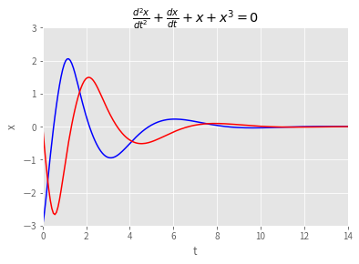

```python
def myODE(t, y):
    return [y[1], -y[0] -y[0]**3 -y[1]]

w = 14
sol1 = solve_ivp(myODE, [0, w], [-3, 4], t_eval = np.linspace(0, w, 200))
sol2 = solve_ivp(myODE, [0, w], [0, -8], t_eval = np.linspace(0, w, 200))

plt.figure(figsize=(6, 4))
plt.plot(sol1.t,sol1.y[0], 'b-', sol2.t, sol2.y[0], 'r-')
plt.axis((0, w, -3, 3))
plt.xlabel('t')
plt.ylabel('x')
plt.title(r'$\frac{d^2x}{dt^2} +\frac{dx}{dt} +x +x^3=0$')
plt.show()
```

## 3.12 Solving Systems of Linear Equations

When physical systems are coupled, the mathematical model of the system usually consists of a set of coupled DEs

$ \begin{align*} m_1 \ddot{x}_1 &=-k_1 x_1 +k_2 (x_2 -x_1) \\ m_2 \ddot{x}_2 &=-k_2 (x_2 -x_1) \end{align*} $

[figure not shown]

Linear systems with constant coefficients can be solved by uncoupling the system into distinct linear ODEs in each dependent variable

**Example:** Solve the above equation under the assumption that $k_1=6$, $k_2=4$, $m_1=1$, and $m_2=1$ subject to $x_1(0)=0$, $x'_1(0)=1$, $x_2(0)=0$, $x'_2(0)=-1$

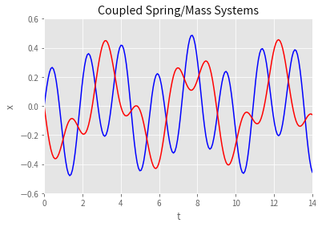

```python
k1 = 6
k2 = 4
m1 = 1
m2 = 1

def myODE(t, y):
    return [y[1], -(k1 +k2)/m1 *y[0] +k2/m1*y[2], y[3], k2/m2*y[0] -k2/m2*y[2]]

w = 14
sol = solve_ivp(myODE, [0, w], [0, 1, 0, -1], t_eval = np.linspace(0, w, 200))

plt.figure(figsize=(6, 4))
plt.plot(sol.t,sol.y[0], 'b-', sol.t, sol.y[2], 'r-')
plt.axis((0, w, -0.6, 0.6))
plt.xlabel('t')
plt.ylabel('x')
plt.title('Coupled Spring/Mass Systems')
plt.show()
```